# 🎨 Customise charts and maps

Source: [`vignettes/articles/customise.Rmd`](https://github.com/Linbojun99/faofishingreport/blob/main/vignettes/articles/customise.Rmd)

📦 **Data**: [FAO Global Capture Production](https://www.fao.org/fishery/collection/capture/en), release **2026.1.0** (published by FAO on 2026-03-30; catches 1950–2024), downloaded from Capture_2026.1.0.zip. Licence [CC BY 4.0](https://creativecommons.org/licenses/by/4.0/). `fao_data_info()` shows the release you use and how to cite it.

All charts and maps follow a few settings, set once per R session with `fao_settings()`. Run it without arguments to see the current settings:

```r
fao_settings()
```

```
#>   lang            en
#>   theme           bw
#>   base_size       12
#>   palette         npg
#>   map_palette     deep-orange
#>   map_center      0
#>   map_projection  longlat
#>   map_land        grey90
#>   map_ocean       NA
#>   grid            FALSE
#>   dpi             600
#>   pptx            FALSE
#>   data_dir        C:/Users/<you>/AppData/Roaming/R/data/R/faofishingreport
#>   online          TRUE
#>   sst             ersst5
#>   silent          FALSE
#>   show_data       TRUE
#>   plot_show       FALSE
#>   font            SimSun
```

`fao_settings(...)` takes the settings as `name = value`, and one more argument, `reset`:

| Argument | Meaning | Default |
| --- | --- | --- |
| `...` | Settings to change, as `name = value` (table below) |  |
| `reset` | `TRUE` first restores all settings to their defaults | `FALSE` |

The settings:

[output not shown]

`fao_settings(reset = TRUE)` restores the defaults. A wrong name or value gives an error at once, with the choices available. Each setting is stored as the R option `faofishingreport.<name>`, so it can also be set with `options()`, e.g. in an `.Rprofile` file. `fao_settings()` returns the current settings invisibly, as a list.

## 🌐 Language

Every analysis has a `lang` argument; `fao_settings(lang = ...)` changes the default for all of them. `"both"` writes Chinese and English together, e.g. “百万吨 (Million Tonnes)” and “挪威 Norway”.

```r
fao_settings(lang = "zh")
fishing_area_country(FAO27$area_data, rank_range = 1:6)
```

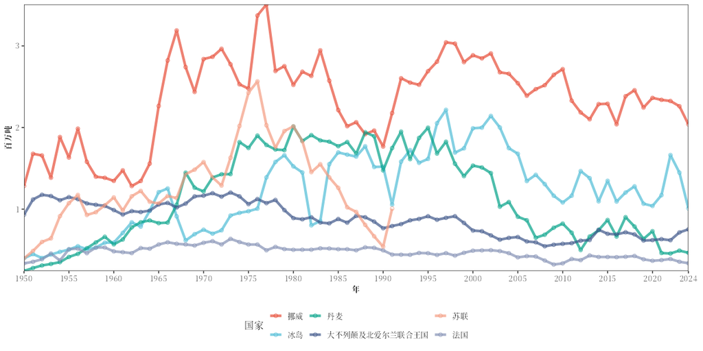

```r
fao_settings(lang = "both")
fishing_area_country(FAO27$area_data, rank_range = 1:6)
```

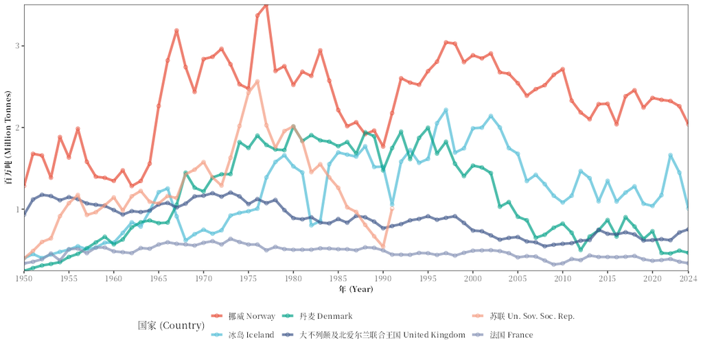

Go back to English with `fao_settings(lang = "en")`. The older argument `ZH = TRUE` still works and means `lang = "zh"`.

## 🖼️ Themes

```r
fao_settings(theme = "classic")
fishing_area_country(FAO27$area_data, rank_range = 1:6)
```

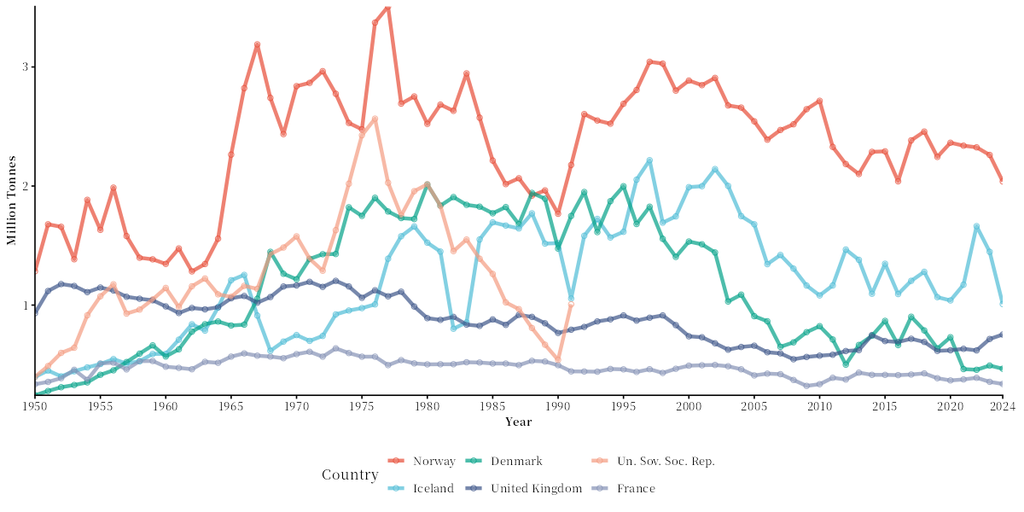

```r
fao_settings(theme = "minimal", base_size = 14)
fishing_area_country(FAO27$area_data, rank_range = 1:6)
```

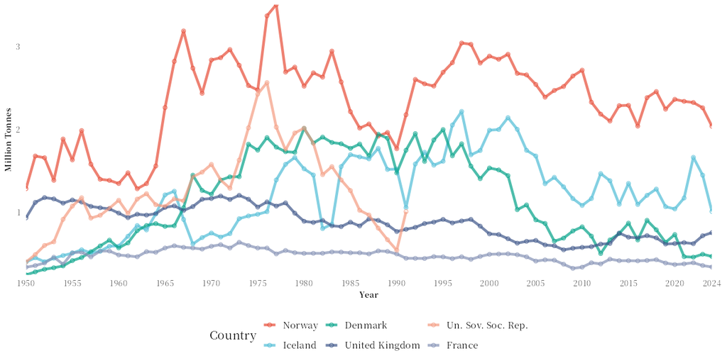

Any ggplot2 theme can be used, e.g. `fao_settings(theme = ggplot2::theme_light(base_size = 13))`.

## 🎨 Colour palettes

`palette` colours countries, species and groups:

```r
fao_settings(theme = "bw", base_size = 12, palette = "lancet")
fishing_area_country(FAO27$area_data, rank_range = 1:6)
```

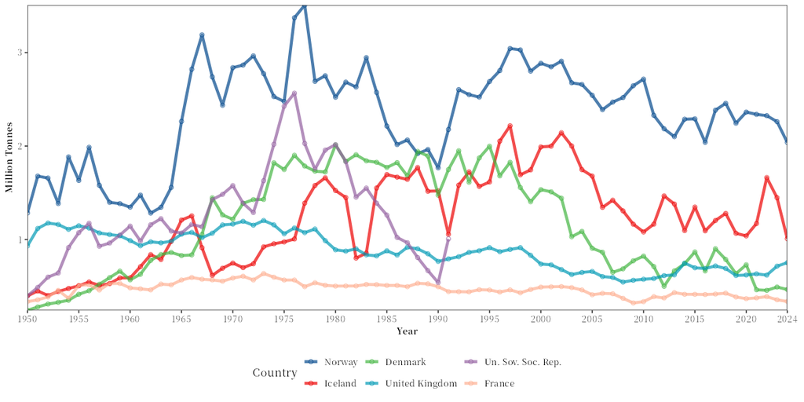

```r
fao_settings(palette = "Okabe-Ito")        # suitable for colour-blind readers
fishing_area_country(FAO27$area_data, rank_range = 1:6)
```

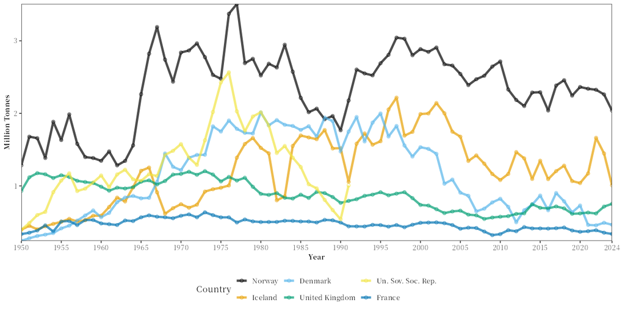

```r
fao_settings(palette = c("#0B2E5B", "#16A6B6", "#F28E2B", "#E15759", "#59A14F", "#B07AA1"))
fishing_area_country(FAO27$area_data, rank_range = 1:6)
fao_settings(palette = "npg")
```

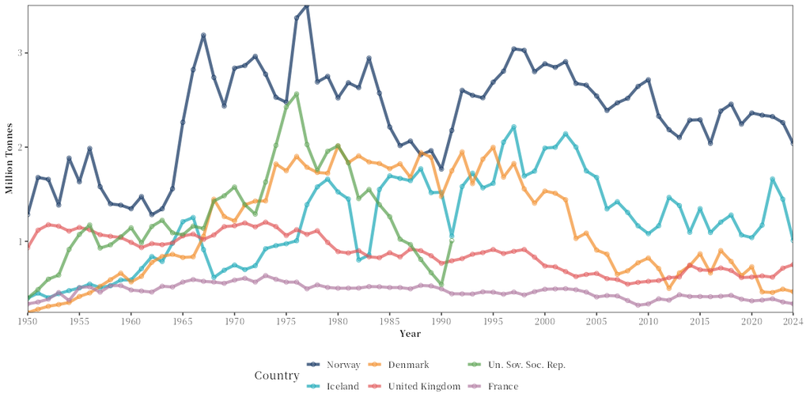

Palettes of the ggsci package include `"npg"`, `"aaas"`, `"nejm"`, `"lancet"`, `"jama"`, `"jco"`, `"d3"`; of RColorBrewer `"Set1"`, `"Set2"`, `"Dark2"`, `"Paired"`; of base R `grDevices::palette.pals()` (e.g. the Okabe-Ito palette for colour-blind readers, Okabe and Ito 2008) and `grDevices::hcl.pals()` (Zeileis et al. 2020). More categories than a palette has are interpolated.

## 🗺️ Map projections

The same map, the catch of each country in area 27, in each projection:

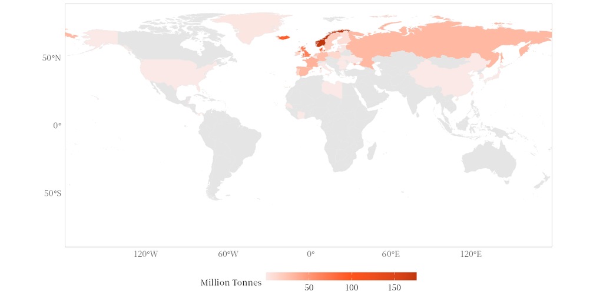

```r
fao_settings(map_projection = "longlat")      # plain longitude-latitude (default)
fishing_area_data("Atlantic, Northeast")
```

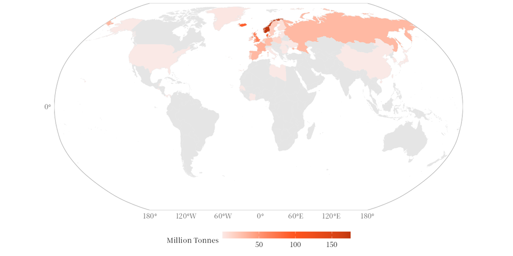

```r
fao_settings(map_projection = "robinson")
fishing_area_data("Atlantic, Northeast")
```

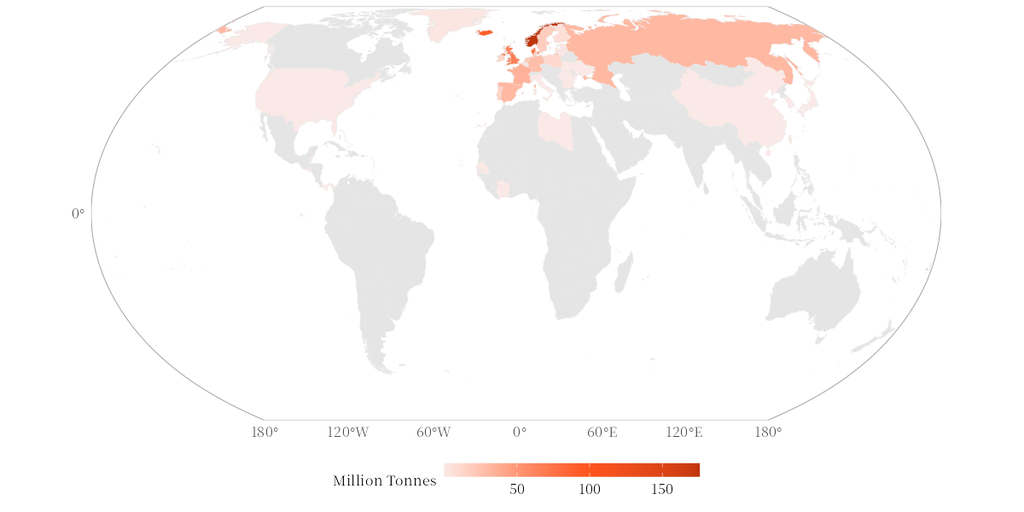

```r
fao_settings(map_projection = "equal_earth")
fishing_area_data("Atlantic, Northeast")
```

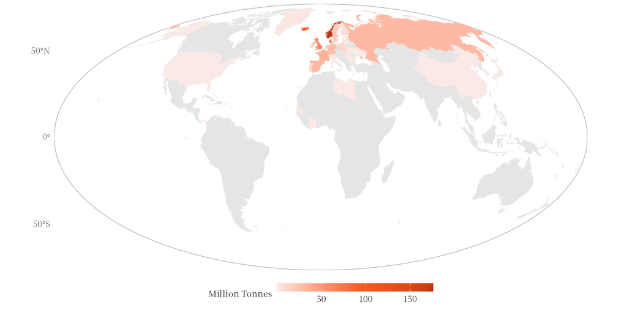

```r
fao_settings(map_projection = "mollweide")
fishing_area_data("Atlantic, Northeast")
```

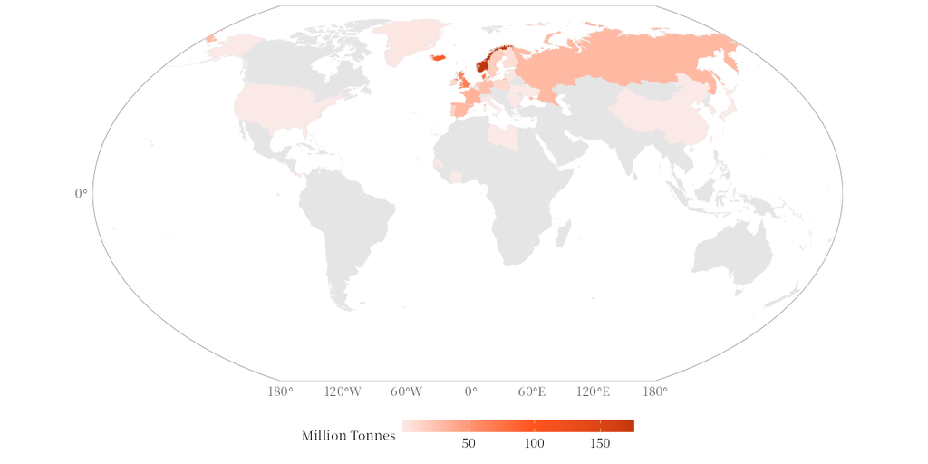

```r
fao_settings(map_projection = "winkel_tripel")
fishing_area_data("Atlantic, Northeast")
```

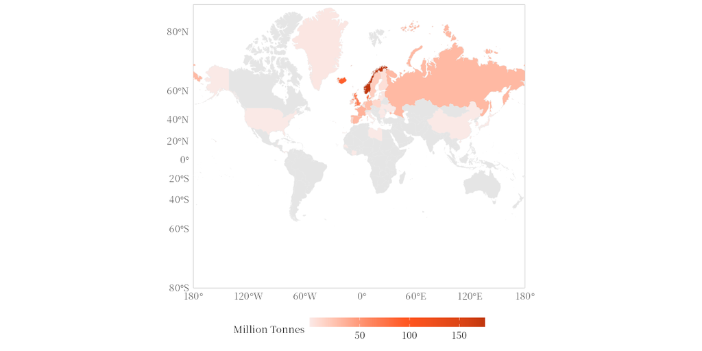

```r
fao_settings(map_projection = "mercator")
fishing_area_data("Atlantic, Northeast")
```

The named projections and the PROJ projection each one uses (the maps are drawn with sf, which uses the PROJ library):

| `map_projection` | Projection | PROJ | Properties |
| --- | --- | --- | --- |
| `"longlat"` | Plain longitude-latitude (equidistant cylindrical, plate carrée) | `EPSG:4326`; `+proj=eqc` with `map_center = 180` | Simple; areas far from the equator are enlarged |
| `"robinson"` | Robinson (Robinson 1974) | `+proj=robin` | Compromise world map: neither equal-area nor conformal |
| `"equal_earth"` | Equal Earth (Šavrič et al. 2019) | `+proj=eqearth` | Equal-area, with straight parallels |
| `"mollweide"` | Mollweide (Snyder 1987) | `+proj=moll` | Equal-area, elliptical outline |
| `"winkel_tripel"` | Winkel tripel | `+proj=wintri` | Compromise world map with low overall distortion |
| `"mercator"` | Mercator (Snyder 1987) | `+proj=merc` | Conformal; areas grow strongly towards the poles, cut at 80° S and 84° N |

Any other projection can be given as a PROJ string or EPSG code, e.g. `fao_settings(map_projection = "+proj=natearth")` or `"EPSG:3857"`.

## 🌏 Pacific-centred maps

`map_center = 180` shows longitudes 0 to 360, with the Pacific in the centre. Areas and countries that the data split at the dateline (e.g. the Pacific areas, Russia) are joined again:

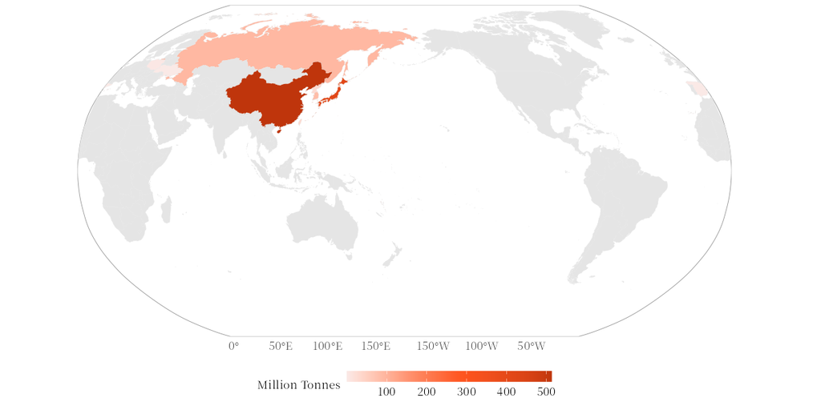

```r
fao_settings(map_projection = "robinson", map_center = 180)
fishing_area_data("Pacific, Northwest")
```

Fishing area maps show the land without country borders, and the analysed country in red:

```r
country_analysis("Norway")
```

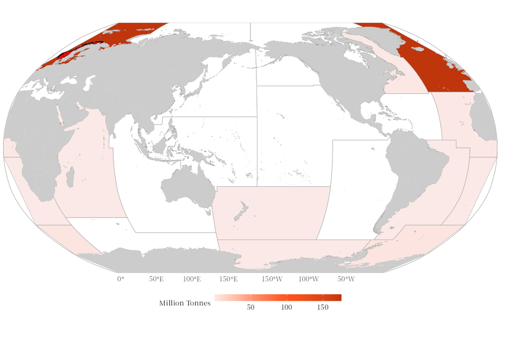

Countries are drawn from the Natural Earth map units (1:50m), matched to the FAO countries on their ISO 3 codes; the fishing areas from the FAO layer of the major fishing areas, simplified for world maps.

## 🖌️ Map colours

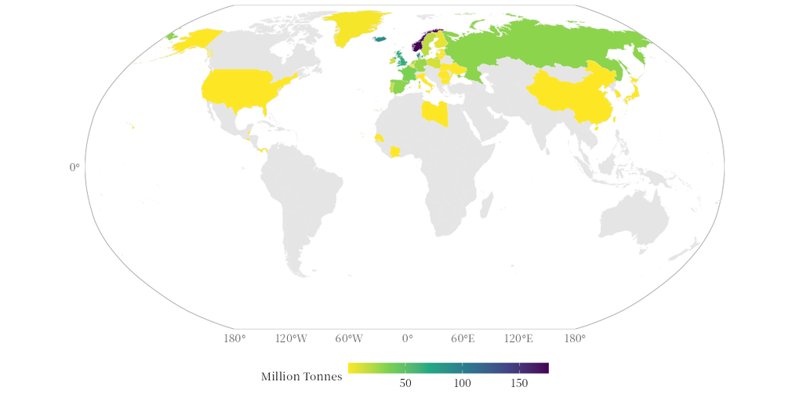

```r
fao_settings(map_projection = "robinson", map_center = 0, map_palette = "viridis")
fishing_area_data("Atlantic, Northeast")
```

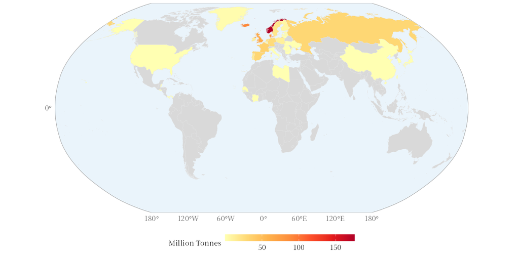

```r
fao_settings(map_palette = "YlOrRd", map_land = "grey85", map_ocean = "#EAF4FB")
fishing_area_data("Atlantic, Northeast")
```

The `fill_scale` argument of `fishing_area_data()`, `species_country()` and `country_analysis()` overrides `map_palette` for one call.

## 🔤 Fonts

The font is chosen for the operating system so that Chinese text displays: SimSun on Windows, Songti SC on macOS, Noto Serif CJK SC on Linux, or the next installed Chinese font (and `"sans"` if none is found). Change it with:

```r
fao_font()                            # the current font
fao_settings(font = "Microsoft YaHei")
```

`fao_font()` has one argument:

| Argument | Meaning | Default |
| --- | --- | --- |
| `family` | Font family to use from now on, e.g. `"Microsoft YaHei"`; `NULL` only returns the current font | `NULL` |

It returns the font family name. `fao_settings(font = ...)`, `fao_font(...)` and `options(faofishingreport.font = ...)` do the same. The fonts tried on each system:

| System | Fonts, in order |
| --- | --- |
| Windows | SimSun, NSimSun, Microsoft YaHei, SimHei, DengXian, KaiTi |
| macOS | Songti SC, STSong, PingFang SC, Heiti SC, Hiragino Sans GB, Arial Unicode MS |
| Linux | Noto Serif CJK SC, Noto Sans CJK SC, Source Han Serif SC, Source Han Sans SC, WenQuanYi Zen Hei, WenQuanYi Micro Hei, AR PL UMing CN |

The installed fonts are listed with the systemfonts package. PNG files are drawn with the ragg package, which finds any installed font by name; PowerPoint files use the same font name.

## 📐 Grid lines, resolution and PowerPoint

```r
fao_settings(grid = TRUE)
fishing_area_country(FAO27$area_data, rank_range = 1:6)
fao_settings(grid = FALSE)
```

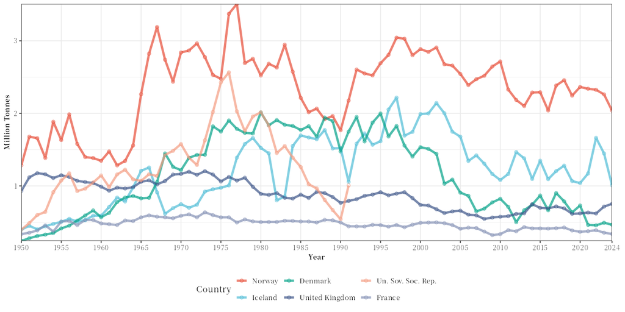

PowerPoint files are written with the eoffice package, installed with faofishingreport; on macOS it also needs [XQuartz](https://www.xquartz.org).

```r
fao_settings(dpi = 300)      # smaller PNG files
fao_settings(pptx = TRUE)    # also editable PowerPoint in figures/pptx/
fishing_area_species(FAO27$area_data, pptx = TRUE)   # or for one call only
```

## ⚙️ Arguments of each function

Besides the settings, the analysis functions have their own arguments; `lang`, `pptx` and `fill_scale` override the settings for one call. Each article has a table of all of them:

| Functions | All arguments |
| --- | --- |
| `fishing_area_data()`, `fishing_area_species()`, `fishing_area_country()` (line widths, point sizes, text sizes and colours) | 🌊 Fishing area analysis |
| `species_country()`, `country_species()`, `country_analysis()` | 🐟 Species and countries |
| `check_fao_update()`, `download_fao_data()`, `load_fao_data()`, `fao_data_info()`, `fao_translate()` | 💾 FAO data |
| Summary analyses, e.g. `stock_status()`, `peak_trend()` | 📈 Composition, stock status and trends, 🔍 Data quality, diversity and fleets |
| `fao_report()` | 📝 Assessment report: Word, LaTeX and PDF |

## 📝 Translations

Chinese names of countries, species and areas come from FAO. The Chinese names of ISSCAAP groups, major groups and income groups (`inst/extdata/group_names_zh.csv`) and all chart labels (`inst/extdata/chart_labels.csv`) are plain CSV files: edit them in the package source and reinstall the package to change the wording.

## 📖 References

FAO (2024). FAO Major Fishing Areas for Statistical Purposes. In: FAO Fisheries and Aquaculture Division [online]. Licence: CC-BY 4.0. https://www.fao.org/fishery/geonetwork?uuid=ac02a460-da52-11dc-9d70-0017f293bd28 (the area boundaries of the fishing area maps, bundled as `inst/extdata/FAO_AREAS_CWP.shp`)

Guo, K. *eoffice: Export or Graph and Tables to ‘Microsoft’ Office and Import Figures and Tables*. R package. [doi:10.32614/CRAN.package.eoffice](https://doi.org/10.32614/CRAN.package.eoffice)

Harrower, M. and Brewer, C.A. (2003). ColorBrewer.org: an online tool for selecting colour schemes for maps. *The Cartographic Journal* 40(1): 27–37. [doi:10.1179/000870403235002042](https://doi.org/10.1179/000870403235002042)

Massicotte, P. and South, A. *rnaturalearth: World Map Data from Natural Earth*. R package. [doi:10.32614/CRAN.package.rnaturalearth](https://doi.org/10.32614/CRAN.package.rnaturalearth)

Natural Earth. Admin 0 – Details, map units, 1:50m. https://www.naturalearthdata.com/downloads/50m-cultural-vectors/50m-admin-0-details/

Okabe, M. and Ito, K. (2008). Color Universal Design (CUD): how to make figures and presentations that are friendly to colorblind people. https://jfly.uni-koeln.de/color/

Pebesma, E. (2018). Simple features for R: standardized support for spatial vector data. *The R Journal* 10(1): 439–446. [doi:10.32614/RJ-2018-009](https://doi.org/10.32614/RJ-2018-009)

Pedersen, T.L. and Shemanarev, M. *ragg: Graphic Devices Based on AGG*. R package. [doi:10.32614/CRAN.package.ragg](https://doi.org/10.32614/CRAN.package.ragg)

PROJ contributors (2026). *PROJ coordinate transformation software library*. Open Source Geospatial Foundation. https://proj.org/. [doi:10.5281/zenodo.5884394](https://doi.org/10.5281/zenodo.5884394)

Robinson, A.H. (1974). A new map projection: its development and characteristics. *International Yearbook of Cartography* 14: 145–155.

Šavrič, B., Patterson, T. and Jenny, B. (2019). The Equal Earth map projection. *International Journal of Geographical Information Science* 33(3): 454–465. [doi:10.1080/13658816.2018.1504949](https://doi.org/10.1080/13658816.2018.1504949)

Snyder, J.P. (1987). *Map Projections: A Working Manual*. U.S. Geological Survey Professional Paper 1395. Washington, DC: U.S. Government Printing Office. [doi:10.3133/pp1395](https://doi.org/10.3133/pp1395)

Wickham, H. (2016). *ggplot2: Elegant Graphics for Data Analysis*. New York: Springer. [doi:10.1007/978-3-319-24277-4](https://doi.org/10.1007/978-3-319-24277-4)

Xiao, N. *ggsci: Scientific Journal and Sci-Fi Themed Color Palettes for ‘ggplot2’*. R package. [doi:10.32614/CRAN.package.ggsci](https://doi.org/10.32614/CRAN.package.ggsci)

Zeileis, A., Fisher, J.C., Hornik, K., Ihaka, R., McWhite, C.D., Murrell, P., Stauffer, R. and Wilke, C.O. (2020). colorspace: a toolbox for manipulating and assessing colors and palettes. *Journal of Statistical Software* 96(1): 1–49. [doi:10.18637/jss.v096.i01](https://doi.org/10.18637/jss.v096.i01)